# Heart Disease Prediction

Ekam Samra and Ajayveer Punia

2025-03-05

## Introduction

Heart disease is the leading cause of death globally, responsible for nearly 18 million deaths annually. This project explores a dataset containing clinical features from over 900 patients to predict heart disease risks.

- **Dataset Source:** Heart Failure Prediction - https://www.kaggle.com/datasets/fedesoriano/heart-failure-prediction
- **Variables Listed Below:**
  - **Age:** Ranges from **28 to 77** years, with an **average age of 53.5**.
  - **Sex:** Two categories (**M, F**) with **more males (725 out of 918)**.
  - **Chest Pain Type:** Four categories (**ASY, ATA, NAP, TA**), with **ASY (Asymptomatic) being the most common**.
  - **RestingBP (Blood Pressure):** Ranges from **0 to 200**, indicating **possible data entry issues** (a BP of **0 is unrealistic**).
  - **Cholesterol:** Ranges from **0 to 603**, with an **average of 198.8**. Some patients have **zero cholesterol**, which might indicate missing data.
  - **FastingBS (Blood Sugar):** Binary (**0 or 1**), with **23.3% having elevated fasting blood sugar**.
  - **RestingECG (Electrocardiogram results):** Three categories (**Normal, ST, LVH**) with **Normal being the most common**.
  - **MaxHR (Maximum Heart Rate):** Ranges from **60 to 202**, with an **average of 136.8**.
  - **Exercise Angina:** Binary (**Y/N**), with **59.6% not experiencing exercise-induced angina**.
  - **Oldpeak (ST Depression):** Ranges from **-2.6 to 6.2**, indicating the **degree of abnormality in heart stress tests**.
  - **ST_Slope:** Three categories (**Up, Flat, Down**) with **Flat being the most common**.
  - **HeartDisease:** Binary (**0 = No, 1 = Yes**), with **55.3% having heart disease**.
- **Objective:** Identify early risk factors using data analysis.

### Summary Statistics

```r
library(dplyr)
```

```r
library(ggplot2)
heart_data <- read.csv("C:/Users/ekamj/Downloads/heart.csv")
summary(heart_data)
```

```
##       Age            Sex            ChestPainType        RestingBP
##  Min.   :28.00   Length:918         Length:918         Min.   :  0.0
##  1st Qu.:47.00   Class :character   Class :character   1st Qu.:120.0
##  Median :54.00   Mode  :character   Mode  :character   Median :130.0
##  Mean   :53.51                                         Mean   :132.4
##  3rd Qu.:60.00                                         3rd Qu.:140.0
##  Max.   :77.00                                         Max.   :200.0
##   Cholesterol      FastingBS       RestingECG            MaxHR
##  Min.   :  0.0   Min.   :0.0000   Length:918         Min.   : 60.0
##  1st Qu.:173.2   1st Qu.:0.0000   Class :character   1st Qu.:120.0
##  Median :223.0   Median :0.0000   Mode  :character   Median :138.0
##  Mean   :198.8   Mean   :0.2331                      Mean   :136.8
##  3rd Qu.:267.0   3rd Qu.:0.0000                      3rd Qu.:156.0
##  Max.   :603.0   Max.   :1.0000                      Max.   :202.0
##  ExerciseAngina        Oldpeak          ST_Slope          HeartDisease
##  Length:918         Min.   :-2.6000   Length:918         Min.   :0.0000
##  Class :character   1st Qu.: 0.0000   Class :character   1st Qu.:0.0000
##  Mode  :character   Median : 0.6000   Mode  :character   Median :1.0000
##                     Mean   : 0.8874                      Mean   :0.5534
##                     3rd Qu.: 1.5000                      3rd Qu.:1.0000
##                     Max.   : 6.2000                      Max.   :1.0000
```

## Visualizations

### Cholesterol Levels by Chest Pain Type

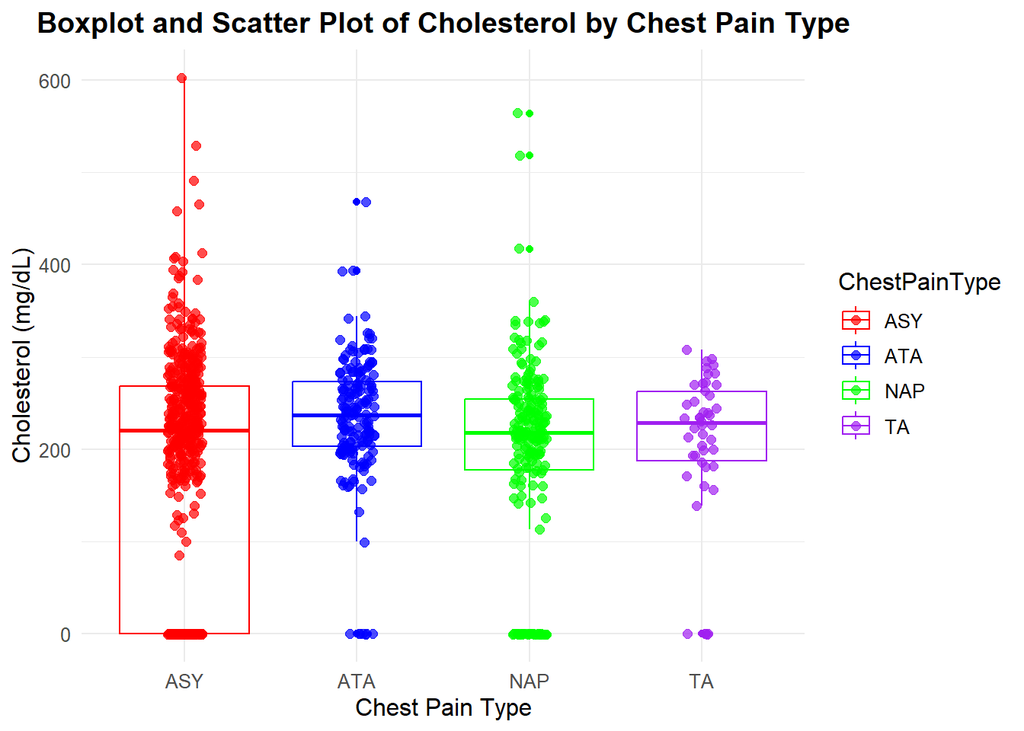

```r
ggplot(heart_data, aes(x = ChestPainType, y = Cholesterol, color = ChestPainType)) +
  geom_boxplot(fill = NA, size = 0.5) +
  geom_jitter(aes(color = ChestPainType), width = 0.1, alpha = 0.7, size = 2) +
  scale_color_manual(values = c("red", "blue", "green", "purple")) +
  labs(title = "Boxplot and Scatter Plot of Cholesterol by Chest Pain Type",
       x = "Chest Pain Type", y = "Cholesterol (mg/dL)") +
  theme_minimal() +
  theme(legend.position = "right",
        text = element_text(size = 12),
        plot.title = element_text(hjust = 0.5, face = "bold"))
```

### Relationship between Age and MaxHR

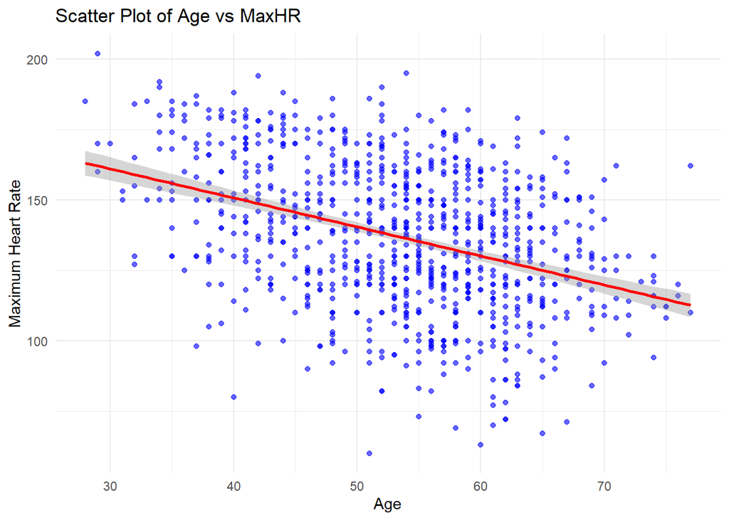

```r
ggplot(heart_data, aes(x = Age, y = MaxHR)) +
  geom_point(alpha = 0.6, color = "blue") +
  geom_smooth(method = "lm", color = "red", se = TRUE) +
  labs(title = "Scatter Plot of Age vs MaxHR",
       x = "Age", y = "Maximum Heart Rate") +
  theme_minimal()
```

**Interpretation:** - There is a **negative correlation**: As people age, their maximum heart rate tends to decline. - This is an expected physiological trend and aligns with known medical findings about cardiovascular function and aging.

## Data Manipulation

### Filtering Data for High-Risk Individuals

```r
heart_high_risk <- heart_data %>% filter(Cholesterol > 240 & HeartDisease == 1)
head(heart_high_risk)
```

```
##   Age Sex ChestPainType RestingBP Cholesterol FastingBS RestingECG MaxHR
## 1  60   M           ASY       100         248         0     Normal   125
## 2  36   M           ATA       120         267         0     Normal   160
## 3  44   M           ATA       150         288         0     Normal   150
## 4  53   M           NAP       145         518         0     Normal   130
## 5  65   M           ASY       140         306         1     Normal    87
## 6  54   F           NAP       130         294         0         ST   100
##   ExerciseAngina Oldpeak ST_Slope HeartDisease
## 1              N     1.0     Flat            1
## 2              N     3.0     Flat            1
## 3              Y     3.0     Flat            1
## 4              N     0.0     Flat            1
## 5              Y     1.5     Flat            1
## 6              Y     0.0     Flat            1
```

**Insight:** This subset represents patients with high cholesterol who already have heart disease, helping focus preventive efforts.

## Statistical Analyses

### Correlation Between Cholesterol and MaxHR

```r
cor(heart_data$Cholesterol, heart_data$MaxHR, use = "complete.obs")
```

```
## [1] 0.2357924
```

**Interpretation:** - The correlation coefficient is **0.236**, suggesting a weak positive relationship. - This means that cholesterol levels and MaxHR are **not strongly linked**, implying that other factors, such as overall cardiovascular fitness, play a larger role.

### T-Test: Cholesterol Levels by Exercise Angina

```r
t_test_result <- t.test(heart_data$Cholesterol ~ heart_data$ExerciseAngina)
t_test_result
```

```
##
##  Welch Two Sample t-test
##
## data:  heart_data$Cholesterol by heart_data$ExerciseAngina
## t = 1.0105, df = 727.35, p-value = 0.3126
## alternative hypothesis: true difference in means between group N and group Y is not equal to 0
## 95 percent confidence interval:
##  -7.176851 22.399920
## sample estimates:
## mean in group N mean in group Y
##        201.8757        194.2642
```

**Interpretation:** - **p-value: 0.3126** → Since this is greater than 0.05, we **fail to reject the null hypothesis**. - This suggests that **cholesterol levels do not significantly differ** between people who experience angina and those who do not.

### Linear Regression: Cholesterol and MaxHR

```r
lm_result <- lm(MaxHR ~ Cholesterol, data = heart_data)
summary(lm_result)
```

```
##
## Call:
## lm(formula = MaxHR ~ Cholesterol, data = heart_data)
##
## Residuals:
##    Min     1Q Median     3Q    Max
## -82.03 -17.48   0.99  18.46  64.91
##
## Coefficients:
##              Estimate Std. Error t value Pr(>|t|)
## (Intercept) 1.259e+02  1.696e+00  74.249  < 2e-16 ***
## Cholesterol 5.488e-02  7.474e-03   7.343  4.6e-13 ***
## ---
## Signif. codes:  0 '***' 0.001 '**' 0.01 '*' 0.05 '.' 0.1 ' ' 1
##
## Residual standard error: 24.76 on 916 degrees of freedom
## Multiple R-squared:  0.0556, Adjusted R-squared:  0.05457
## F-statistic: 53.93 on 1 and 916 DF,  p-value: 4.597e-13
```

**Interpretation:** - The regression shows a weak relationship between cholesterol and MaxHR. - The R-squared value is low, meaning **cholesterol alone is not a strong predictor of MaxHR**. - Other cardiovascular markers should be considered for a more complete analysis.

## Conclusion

### **Final Thoughts:**

This analysis confirms that while cholesterol levels can be an important indicator, they should be considered **alongside other heart health metrics**. Future research could explore more complex models incorporating multiple factors to improve predictive power for heart disease risk.

Regular health screenings remain essential for early risk detection!